# Jun Pan DATA 607 Project 2 3rd database

Jun Pan

October 6, 2018

United Nations Development Program sets “Zero Hunger” as one of their sustainable development goals (SDGs). The prevalence of undernourishment (% of population) under code SN.ITK.DEFC.ZS are evaluated in the database.

Database source: https://datacatalog.worldbank.org/dataset/sustainable-development-goals

Set environment

```r
library(dplyr)
```

```r
library(tidyr)
library(knitr)
library(ggplot2)
library(stringr)
```

```r
read.csv("C:/Users/tbao/Desktop/CUNY MSDS notes/607/week 6/project 2/World Bank/SDGData.csv")
```

[output not shown]

[output cut: 30296 more lines]

It shows that the database has 91524 rows and 33 columns

```r
sdgdata = read.table("C:/Users/tbao/Desktop/CUNY MSDS notes/607/week 6/project 2/World Bank/SDGData.csv", header=TRUE, sep=",", na.strings = c("", "NA"))
sdgdata$X <- NULL
```

```r
head(sdgdata)
```

```
##   ï..Country.Name Country.Code
## 1      Arab World          ARB
## 2      Arab World          ARB
## 3      Arab World          ARB
## 4      Arab World          ARB
## 5      Arab World          ARB
## 6      Arab World          ARB
##                                                         Indicator.Name
## 1 Access to clean fuels and technologies for cooking (% of population)
## 2                              Access to electricity (% of population)
## 3                 Access to electricity, rural (% of rural population)
## 4                 Access to electricity, urban (% of urban population)
## 5                                             Account (% age 15+) [ts]
## 6                                     Account, female (% age 15+) [ts]
##      Indicator.Code    X1990    X1991    X1992    X1993    X1994    X1995
```

[output cut: 27 more lines]

```r
tail(sdgdata)
```

```
##       ï..Country.Name Country.Code
## 91519        Zimbabwe          ZWE
## 91520        Zimbabwe          ZWE
## 91521        Zimbabwe          ZWE
## 91522        Zimbabwe          ZWE
## 91523        Zimbabwe          ZWE
## 91524        Zimbabwe          ZWE
##                                                                                                                                     Indicator.Name
## 91519                                                            Wage and salaried workers, female (% of female employment) (modeled ILO estimate)
## 91520                                                                Wage and salaried workers, male (% of male employment) (modeled ILO estimate)
## 91521                                                              Wage and salaried workers, total (% of total employment) (modeled ILO estimate)
## 91522                                             Water productivity, total (constant 2010 US$ GDP per cubic meter of total freshwater withdrawal)
## 91523 Women making their own informed decisions regarding sexual relations, contraceptive use and reproductive health care  (% of women age 15-49)
## 91524                                                                               Women who were first married by age 18 (% of women ages 20-24)
##          Indicator.Code X1990 X1991 X1992 X1993 X1994 X1995 X1996 X1997
```

[output cut: 20 more lines]

change the names of the columns

```r
names(sdgdata)[1] <- "country_name"
names(sdgdata)[2] <- "country_code"
names(sdgdata)[3] <- "indicator_name"
names(sdgdata)[4] <- "indicator_code"
```

```r
head(sdgdata)
```

```
##   country_name country_code
## 1   Arab World          ARB
## 2   Arab World          ARB
## 3   Arab World          ARB
## 4   Arab World          ARB
## 5   Arab World          ARB
## 6   Arab World          ARB
##                                                         indicator_name
## 1 Access to clean fuels and technologies for cooking (% of population)
## 2                              Access to electricity (% of population)
## 3                 Access to electricity, rural (% of rural population)
## 4                 Access to electricity, urban (% of urban population)
## 5                                             Account (% age 15+) [ts]
## 6                                     Account, female (% age 15+) [ts]
##      indicator_code    X1990    X1991    X1992    X1993    X1994    X1995
```

[output cut: 27 more lines]

Check how many countries in the database

```r
sdgdata %>% dplyr::select(country_name) %>% dplyr::n_distinct()
```

```
## [1] 263
```

list names of all 263 countires

```r
countries <- unlist(sdgdata %>% dplyr::select(country_name) %>% dplyr::distinct())
names(countries) <- NULL
rownames(countries) <- c()
kable(countries, format="markdown")
```

| x |
| --- |
| Arab World |
| Caribbean small states |
| Central Europe and the Baltics |
| Early-demographic dividend |
| East Asia & Pacific |
| East Asia & Pacific (excluding high income) |
| East Asia & Pacific (IDA & IBRD) |
| Euro area |
| Europe & Central Asia |
| Europe & Central Asia (excluding high income) |
| Europe & Central Asia (IDA & IBRD) |
| European Union |
| Fragile and conflict affected situations |
| Heavily indebted poor countries (HIPC) |
| High income |
| IBRD only |
| IDA & IBRD total |
| IDA blend |
| IDA only |
| IDA total |
| Late-demographic dividend |
| Latin America & Caribbean |
| Latin America & Caribbean (excluding high income) |
| Latin America & Caribbean (IDA & IBRD) |
| Least developed countries: UN classification |
| Low & middle income |
| Low income |
| Lower middle income |
| Middle East & North Africa |
| Middle East & North Africa (excluding high income) |

[output cut: 233 more lines]

Create a subset for indicator Prevalence of undernourishment (% of population) under code SN.ITK.DEFC.ZS For the years before 2000 and after 2015, we do not have the data. So we are going to exclude those columnes inour subset of database.

```r
sdg_subset <- sdgdata %>% dplyr::filter(sdgdata$indicator_code == "SN.ITK.DEFC.ZS")
head(sdg_subset)
```

```
##                                  country_name country_code
## 1                                  Arab World          ARB
## 2                      Caribbean small states          CSS
## 3              Central Europe and the Baltics          CEB
## 4                  Early-demographic dividend          EAR
## 5                         East Asia & Pacific          EAS
## 6 East Asia & Pacific (excluding high income)          EAP
##                                     indicator_name indicator_code X1990
## 1 Prevalence of undernourishment (% of population) SN.ITK.DEFC.ZS    NA
## 2 Prevalence of undernourishment (% of population) SN.ITK.DEFC.ZS    NA
## 3 Prevalence of undernourishment (% of population) SN.ITK.DEFC.ZS    NA
## 4 Prevalence of undernourishment (% of population) SN.ITK.DEFC.ZS    NA
## 5 Prevalence of undernourishment (% of population) SN.ITK.DEFC.ZS    NA
## 6 Prevalence of undernourishment (% of population) SN.ITK.DEFC.ZS    NA
##   X1991 X1992 X1993 X1994 X1995 X1996 X1997 X1998 X1999     X2000
```

[output cut: 27 more lines]

```r
sdg_subset$X1990 <- NULL
sdg_subset$X1991 <- NULL
sdg_subset$X1992 <- NULL
sdg_subset$X1993 <- NULL
sdg_subset$X1994 <- NULL
sdg_subset$X1995 <- NULL
sdg_subset$X1996 <- NULL
sdg_subset$X1997 <- NULL
sdg_subset$X1998 <- NULL
sdg_subset$X1999 <- NULL
sdg_subset$X2016 <- NULL
sdg_subset$X2017 <- NULL

head(sdg_subset)
```

```
##                                  country_name country_code
## 1                                  Arab World          ARB
## 2                      Caribbean small states          CSS
## 3              Central Europe and the Baltics          CEB
## 4                  Early-demographic dividend          EAR
## 5                         East Asia & Pacific          EAS
## 6 East Asia & Pacific (excluding high income)          EAP
##                                     indicator_name indicator_code
## 1 Prevalence of undernourishment (% of population) SN.ITK.DEFC.ZS
## 2 Prevalence of undernourishment (% of population) SN.ITK.DEFC.ZS
## 3 Prevalence of undernourishment (% of population) SN.ITK.DEFC.ZS
## 4 Prevalence of undernourishment (% of population) SN.ITK.DEFC.ZS
## 5 Prevalence of undernourishment (% of population) SN.ITK.DEFC.ZS
## 6 Prevalence of undernourishment (% of population) SN.ITK.DEFC.ZS
##       X2000     X2001     X2002     X2003     X2004     X2005     X2006
```

[output cut: 20 more lines]

```r
dim(sdg_subset)
```

```
## [1] 263  20
```

keep only Completed cases in subset

```r
sdg_subset <- sdg_subset[complete.cases(sdg_subset), ]
```

```r
dim(sdg_subset)
```

```
## [1] 214  20
```

Tidy subset:(1)drop indicator_name and indicator_code columes; (2)combine the columes from X2000 to X2015 to a new columes with the name of “year”

```r
sdg_subset_transform1 <- tidyr::gather(sdg_subset, "year", "undernourishment_SN.ITK.DEFC.ZS", 5:20)

sdg_subset_transform1$indicator_code <- NULL
sdg_subset_transform1$indicator_name <- NULL

head(sdg_subset_transform1)
```

```
##                                  country_name country_code  year
## 1                                  Arab World          ARB X2000
## 2                      Caribbean small states          CSS X2000
## 3              Central Europe and the Baltics          CEB X2000
## 4                  Early-demographic dividend          EAR X2000
## 5                         East Asia & Pacific          EAS X2000
## 6 East Asia & Pacific (excluding high income)          EAP X2000
##   undernourishment_SN.ITK.DEFC.ZS
## 1                       11.006685
## 2                        9.534613
## 3                        3.276725
## 4                       18.039847
## 5                       16.200267
## 6                       17.896592
```

Calculate the mean for all countries for each year from 2000 to 2015.

```r
sdg_meanPerYear <-
  sdg_subset_transform1 %>%
  dplyr::group_by(year) %>%
  dplyr::summarise(mean = mean(undernourishment_SN.ITK.DEFC.ZS))

for (i in 1:nrow(sdg_meanPerYear)) {
  sdg_meanPerYear[i,1] <- stringr::str_extract(sdg_meanPerYear[i,1], "[0-9]{4,4}")
}

print(sdg_meanPerYear)
```

```
## # A tibble: 16 x 2
##    year   mean
##    <chr> <dbl>
##  1 2000   15.7
##  2 2001   15.3
##  3 2002   15.0
##  4 2003   14.6
##  5 2004   14.2
##  6 2005   13.7
##  7 2006   13.2
##  8 2007   12.8
##  9 2008   12.4
## 10 2009   12.1
## 11 2010   11.8
## 12 2011   11.5
## 13 2012   11.3
## 14 2013   11.1
## 15 2014   11.1
## 16 2015   11.2
```

Calculate the mean prevalence of undernourishment for each country from year 2000 to 2015.

```r
sdg_meanPerCountry <-
  sdg_subset_transform1 %>%
    dplyr::group_by(country_name) %>%
    dplyr::summarise(country_mean = mean(undernourishment_SN.ITK.DEFC.ZS))

names(sdg_meanPerCountry)[1] <- "country_name"

for (i in 1:nrow(sdg_meanPerYear)) {
  sdg_meanPerYear[i,1] <- stringr::str_extract(sdg_meanPerYear[i,1], "[0-9]{4,4}")
}

print(sdg_meanPerCountry)
```

```
## # A tibble: 214 x 2
##    country_name        country_mean
##    <fct>                      <dbl>
##  1 Afghanistan                30.5
##  2 Albania                     8.18
##  3 Algeria                     7.46
##  4 Angola                     27.7
##  5 Antigua and Barbuda        31.7
##  6 Arab World                 10.5
##  7 Argentina                   4.17
##  8 Armenia                     9.71
##  9 Australia                   2.5
## 10 Austria                     2.5
## # ... with 204 more rows
```

Calculate the mean prevalence of undernourishment of 214 countries (yr 2000 to yr 2015)

```r
sdg_meanPerCountry
```

```
## # A tibble: 214 x 2
##    country_name        country_mean
##    <fct>                      <dbl>
##  1 Afghanistan                30.5
##  2 Albania                     8.18
##  3 Algeria                     7.46
##  4 Angola                     27.7
##  5 Antigua and Barbuda        31.7
##  6 Arab World                 10.5
##  7 Argentina                   4.17
##  8 Armenia                     9.71
##  9 Australia                   2.5
## 10 Austria                     2.5
## # ... with 204 more rows
```

Summary statistics for the mean prevalence of all countries

```r
unlist(sdg_meanPerCountry %>% dplyr::summarise(mean=mean(country_mean),
                                median=median(country_mean),
                                IQR = IQR(country_mean),
                                sd = sd(country_mean),
                                min = min(country_mean),
                                max = max(country_mean)))
```

```
##      mean    median       IQR        sd       min       max
## 12.945129  9.492923 14.246875 10.920664  2.493750 52.931250
```

mean prevelance of undernourishment per country

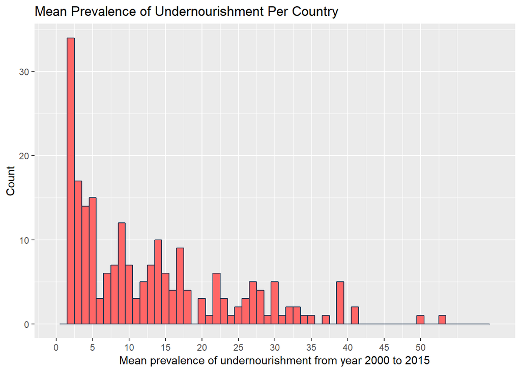

```r
barfill <- "#FF6666"
barlines <- "#1F3552"

e <- ggplot(sdg_meanPerCountry, aes(x = country_mean)) +
        geom_histogram(aes(y = ..count..), binwidth = 1,
                       colour = barlines, fill = barfill) +
        scale_x_continuous(name = "Mean prevalence of undernourishment from year 2000 to 2015",
                           breaks = seq(0, 50, 5),
                           limits=c(0, 60)) +
        scale_y_continuous(name = "Count") +
        ggtitle("Mean Prevalence of Undernourishment Per Country")
e
```

mean prevalence of undernourishment from year 2000 to 2015

```r
sdg_meanPerYear
```

```
## # A tibble: 16 x 2
##    year   mean
##    <chr> <dbl>
##  1 2000   15.7
##  2 2001   15.3
##  3 2002   15.0
##  4 2003   14.6
##  5 2004   14.2
##  6 2005   13.7
##  7 2006   13.2
##  8 2007   12.8
##  9 2008   12.4
## 10 2009   12.1
## 11 2010   11.8
## 12 2011   11.5
## 13 2012   11.3
## 14 2013   11.1
## 15 2014   11.1
## 16 2015   11.2
```

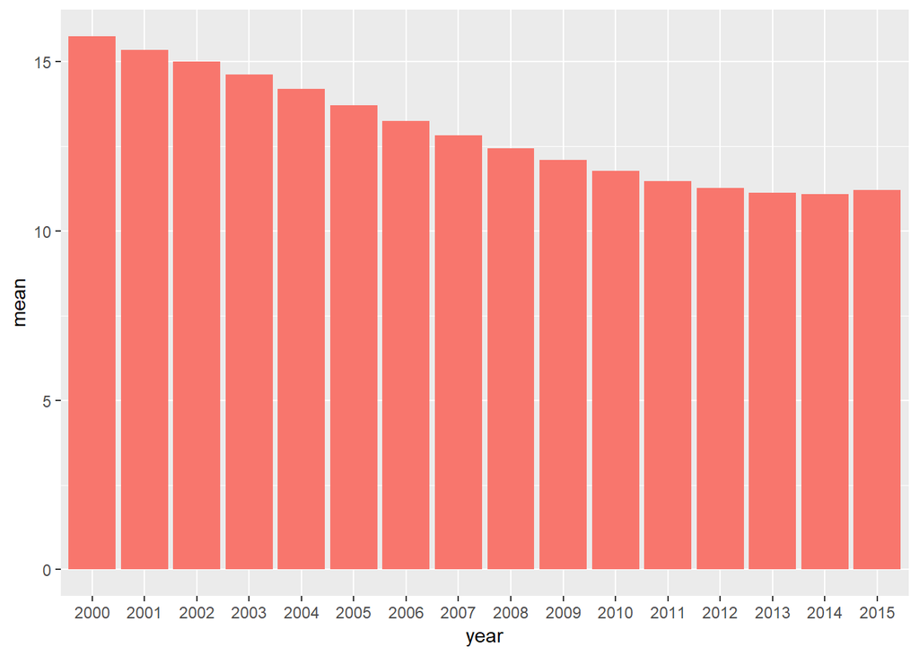

```r
f <- ggplot() + geom_bar(aes(y = mean, x = year, fill = "#1F3552"), data = sdg_meanPerYear, stat = "identity") + guides(fill=FALSE)
f
```

Rank countries of prevelance of undernourishment in descending order

```r
sdg_meanPerCountry %>% dplyr::arrange(desc(country_mean))
```

```
## # A tibble: 214 x 2
##    country_name              country_mean
##    <fct>                            <dbl>
##  1 Haiti                             52.9
##  2 Zambia                            49.8
##  3 Central African Republic          41.5
##  4 Rwanda                            41.2
##  5 Liberia                           39
##  6 Korea, Dem. People's Rep.         38.9
##  7 Zimbabwe                          38.8
##  8 Chad                              38.7
##  9 Tajikistan                        38.5
## 10 Ethiopia                          37.4
## # ... with 204 more rows
```